Parcial Final Machine learning presentado por: Cristian Colpas

```python
import pandas as pd
import matplotlib.pyplot as plt
import numpy as np
import seaborn as sns
from sklearn.model_selection import train_test_split
```

# data fraud

```python
fraudiden= pd.read_csv('C:/Users/cacolpas/Desktop/parcial/fraude/train_identity.csv')
fraudtran= pd.read_csv('C:/Users/cacolpas/Desktop/parcial/fraude/train_transaction.csv')
```

En esta parte se realiza la lectura de los dos dataframe de entrenamiento, train identity y train transaction

```python
print(fraudiden.columns.values)
```

```
['TransactionID' 'id_01' 'id_02' 'id_03' 'id_04' 'id_05' 'id_06' 'id_07'
 'id_08' 'id_09' 'id_10' 'id_11' 'id_12' 'id_13' 'id_14' 'id_15' 'id_16'
 'id_17' 'id_18' 'id_19' 'id_20' 'id_21' 'id_22' 'id_23' 'id_24' 'id_25'
 'id_26' 'id_27' 'id_28' 'id_29' 'id_30' 'id_31' 'id_32' 'id_33' 'id_34'
 'id_35' 'id_36' 'id_37' 'id_38' 'DeviceType' 'DeviceInfo']
```

```python
print(fraudtran.columns.values)
```

```
['TransactionID' 'isFraud' 'TransactionDT' 'TransactionAmt' 'ProductCD'
 'card1' 'card2' 'card3' 'card4' 'card5' 'card6' 'addr1' 'addr2' 'dist1'
 'dist2' 'P_emaildomain' 'R_emaildomain' 'C1' 'C2' 'C3' 'C4' 'C5' 'C6'
 'C7' 'C8' 'C9' 'C10' 'C11' 'C12' 'C13' 'C14' 'D1' 'D2' 'D3' 'D4' 'D5'
 'D6' 'D7' 'D8' 'D9' 'D10' 'D11' 'D12' 'D13' 'D14' 'D15' 'M1' 'M2' 'M3'
 'M4' 'M5' 'M6' 'M7' 'M8' 'M9' 'V1' 'V2' 'V3' 'V4' 'V5' 'V6' 'V7' 'V8'
 'V9' 'V10' 'V11' 'V12' 'V13' 'V14' 'V15' 'V16' 'V17' 'V18' 'V19' 'V20'
 'V21' 'V22' 'V23' 'V24' 'V25' 'V26' 'V27' 'V28' 'V29' 'V30' 'V31' 'V32'
 'V33' 'V34' 'V35' 'V36' 'V37' 'V38' 'V39' 'V40' 'V41' 'V42' 'V43' 'V44'
 'V45' 'V46' 'V47' 'V48' 'V49' 'V50' 'V51' 'V52' 'V53' 'V54' 'V55' 'V56'
 'V57' 'V58' 'V59' 'V60' 'V61' 'V62' 'V63' 'V64' 'V65' 'V66' 'V67' 'V68'
 'V69' 'V70' 'V71' 'V72' 'V73' 'V74' 'V75' 'V76' 'V77' 'V78' 'V79' 'V80'
 'V81' 'V82' 'V83' 'V84' 'V85' 'V86' 'V87' 'V88' 'V89' 'V90' 'V91' 'V92'
 'V93' 'V94' 'V95' 'V96' 'V97' 'V98' 'V99' 'V100' 'V101' 'V102' 'V103'
 'V104' 'V105' 'V106' 'V107' 'V108' 'V109' 'V110' 'V111' 'V112' 'V113'
 'V114' 'V115' 'V116' 'V117' 'V118' 'V119' 'V120' 'V121' 'V122' 'V123'
 'V124' 'V125' 'V126' 'V127' 'V128' 'V129' 'V130' 'V131' 'V132' 'V133'
 'V134' 'V135' 'V136' 'V137' 'V138' 'V139' 'V140' 'V141' 'V142' 'V143'
 'V144' 'V145' 'V146' 'V147' 'V148' 'V149' 'V150' 'V151' 'V152' 'V153'
 'V154' 'V155' 'V156' 'V157' 'V158' 'V159' 'V160' 'V161' 'V162' 'V163'
 'V164' 'V165' 'V166' 'V167' 'V168' 'V169' 'V170' 'V171' 'V172' 'V173'
 'V174' 'V175' 'V176' 'V177' 'V178' 'V179' 'V180' 'V181' 'V182' 'V183'
 'V184' 'V185' 'V186' 'V187' 'V188' 'V189' 'V190' 'V191' 'V192' 'V193'
 'V194' 'V195' 'V196' 'V197' 'V198' 'V199' 'V200' 'V201' 'V202' 'V203'
 'V204' 'V205' 'V206' 'V207' 'V208' 'V209' 'V210' 'V211' 'V212' 'V213'
 'V214' 'V215' 'V216' 'V217' 'V218' 'V219' 'V220' 'V221' 'V222' 'V223'
 'V224' 'V225' 'V226' 'V227' 'V228' 'V229' 'V230' 'V231' 'V232' 'V233'
 'V234' 'V235' 'V236' 'V237' 'V238' 'V239' 'V240' 'V241' 'V242' 'V243'
 'V244' 'V245' 'V246' 'V247' 'V248' 'V249' 'V250' 'V251' 'V252' 'V253'
 'V254' 'V255' 'V256' 'V257' 'V258' 'V259' 'V260' 'V261' 'V262' 'V263'
 'V264' 'V265' 'V266' 'V267' 'V268' 'V269' 'V270' 'V271' 'V272' 'V273'
 'V274' 'V275' 'V276' 'V277' 'V278' 'V279' 'V280' 'V281' 'V282' 'V283'
 'V284' 'V285' 'V286' 'V287' 'V288' 'V289' 'V290' 'V291' 'V292' 'V293'
 'V294' 'V295' 'V296' 'V297' 'V298' 'V299' 'V300' 'V301' 'V302' 'V303'
 'V304' 'V305' 'V306' 'V307' 'V308' 'V309' 'V310' 'V311' 'V312' 'V313'
 'V314' 'V315' 'V316' 'V317' 'V318' 'V319' 'V320' 'V321' 'V322' 'V323'
 'V324' 'V325' 'V326' 'V327' 'V328' 'V329' 'V330' 'V331' 'V332' 'V333'
 'V334' 'V335' 'V336' 'V337' 'V338' 'V339']
```

analisis individual de las columnas de los dos dataframe

```python
fraudmer=pd.merge(fraudtran, fraudiden, on='TransactionID', how='left')
```

se realiza el merge para unir los dos dataframe

```python
print(fraudmer.columns.values)
```

```
['TransactionID' 'isFraud' 'TransactionDT' 'TransactionAmt' 'ProductCD'
 'card1' 'card2' 'card3' 'card4' 'card5' 'card6' 'addr1' 'addr2' 'dist1'
 'dist2' 'P_emaildomain' 'R_emaildomain' 'C1' 'C2' 'C3' 'C4' 'C5' 'C6'
 'C7' 'C8' 'C9' 'C10' 'C11' 'C12' 'C13' 'C14' 'D1' 'D2' 'D3' 'D4' 'D5'
 'D6' 'D7' 'D8' 'D9' 'D10' 'D11' 'D12' 'D13' 'D14' 'D15' 'M1' 'M2' 'M3'
 'M4' 'M5' 'M6' 'M7' 'M8' 'M9' 'V1' 'V2' 'V3' 'V4' 'V5' 'V6' 'V7' 'V8'
 'V9' 'V10' 'V11' 'V12' 'V13' 'V14' 'V15' 'V16' 'V17' 'V18' 'V19' 'V20'
 'V21' 'V22' 'V23' 'V24' 'V25' 'V26' 'V27' 'V28' 'V29' 'V30' 'V31' 'V32'
 'V33' 'V34' 'V35' 'V36' 'V37' 'V38' 'V39' 'V40' 'V41' 'V42' 'V43' 'V44'
 'V45' 'V46' 'V47' 'V48' 'V49' 'V50' 'V51' 'V52' 'V53' 'V54' 'V55' 'V56'
 'V57' 'V58' 'V59' 'V60' 'V61' 'V62' 'V63' 'V64' 'V65' 'V66' 'V67' 'V68'
 'V69' 'V70' 'V71' 'V72' 'V73' 'V74' 'V75' 'V76' 'V77' 'V78' 'V79' 'V80'
 'V81' 'V82' 'V83' 'V84' 'V85' 'V86' 'V87' 'V88' 'V89' 'V90' 'V91' 'V92'
 'V93' 'V94' 'V95' 'V96' 'V97' 'V98' 'V99' 'V100' 'V101' 'V102' 'V103'
 'V104' 'V105' 'V106' 'V107' 'V108' 'V109' 'V110' 'V111' 'V112' 'V113'
 'V114' 'V115' 'V116' 'V117' 'V118' 'V119' 'V120' 'V121' 'V122' 'V123'
 'V124' 'V125' 'V126' 'V127' 'V128' 'V129' 'V130' 'V131' 'V132' 'V133'
 'V134' 'V135' 'V136' 'V137' 'V138' 'V139' 'V140' 'V141' 'V142' 'V143'
 'V144' 'V145' 'V146' 'V147' 'V148' 'V149' 'V150' 'V151' 'V152' 'V153'
 'V154' 'V155' 'V156' 'V157' 'V158' 'V159' 'V160' 'V161' 'V162' 'V163'
 'V164' 'V165' 'V166' 'V167' 'V168' 'V169' 'V170' 'V171' 'V172' 'V173'
 'V174' 'V175' 'V176' 'V177' 'V178' 'V179' 'V180' 'V181' 'V182' 'V183'
 'V184' 'V185' 'V186' 'V187' 'V188' 'V189' 'V190' 'V191' 'V192' 'V193'
 'V194' 'V195' 'V196' 'V197' 'V198' 'V199' 'V200' 'V201' 'V202' 'V203'
 'V204' 'V205' 'V206' 'V207' 'V208' 'V209' 'V210' 'V211' 'V212' 'V213'
 'V214' 'V215' 'V216' 'V217' 'V218' 'V219' 'V220' 'V221' 'V222' 'V223'
 'V224' 'V225' 'V226' 'V227' 'V228' 'V229' 'V230' 'V231' 'V232' 'V233'
 'V234' 'V235' 'V236' 'V237' 'V238' 'V239' 'V240' 'V241' 'V242' 'V243'
 'V244' 'V245' 'V246' 'V247' 'V248' 'V249' 'V250' 'V251' 'V252' 'V253'
 'V254' 'V255' 'V256' 'V257' 'V258' 'V259' 'V260' 'V261' 'V262' 'V263'
 'V264' 'V265' 'V266' 'V267' 'V268' 'V269' 'V270' 'V271' 'V272' 'V273'
 'V274' 'V275' 'V276' 'V277' 'V278' 'V279' 'V280' 'V281' 'V282' 'V283'
 'V284' 'V285' 'V286' 'V287' 'V288' 'V289' 'V290' 'V291' 'V292' 'V293'
 'V294' 'V295' 'V296' 'V297' 'V298' 'V299' 'V300' 'V301' 'V302' 'V303'
 'V304' 'V305' 'V306' 'V307' 'V308' 'V309' 'V310' 'V311' 'V312' 'V313'
 'V314' 'V315' 'V316' 'V317' 'V318' 'V319' 'V320' 'V321' 'V322' 'V323'
 'V324' 'V325' 'V326' 'V327' 'V328' 'V329' 'V330' 'V331' 'V332' 'V333'
 'V334' 'V335' 'V336' 'V337' 'V338' 'V339' 'id_01' 'id_02' 'id_03' 'id_04'
 'id_05' 'id_06' 'id_07' 'id_08' 'id_09' 'id_10' 'id_11' 'id_12' 'id_13'
 'id_14' 'id_15' 'id_16' 'id_17' 'id_18' 'id_19' 'id_20' 'id_21' 'id_22'
 'id_23' 'id_24' 'id_25' 'id_26' 'id_27' 'id_28' 'id_29' 'id_30' 'id_31'
 'id_32' 'id_33' 'id_34' 'id_35' 'id_36' 'id_37' 'id_38' 'DeviceType'
 'DeviceInfo']
```

```python
fraudmer.shape
```

```
(590540, 434)
```

# se puede ver que tenemos en el nuevo dataframe unido 434 columnas y 590540 datos

```python
fraudmer.head()
```

|  | TransactionID | isFraud | TransactionDT | TransactionAmt | ProductCD | card1 | card2 | card3 | card4 | card5 | ... | id_31 | id_32 | id_33 | id_34 | id_35 | id_36 | id_37 | id_38 | DeviceType | DeviceInfo |
| --- | --- | --- | --- | --- | --- | --- | --- | --- | --- | --- | --- | --- | --- | --- | --- | --- | --- | --- | --- | --- | --- |
| 0 | 2987000 | 0 | 86400 | 68.5 | W | 13926 | NaN | 150.0 | discover | 142.0 | ... | NaN | NaN | NaN | NaN | NaN | NaN | NaN | NaN | NaN | NaN |
| 1 | 2987001 | 0 | 86401 | 29.0 | W | 2755 | 404.0 | 150.0 | mastercard | 102.0 | ... | NaN | NaN | NaN | NaN | NaN | NaN | NaN | NaN | NaN | NaN |
| 2 | 2987002 | 0 | 86469 | 59.0 | W | 4663 | 490.0 | 150.0 | visa | 166.0 | ... | NaN | NaN | NaN | NaN | NaN | NaN | NaN | NaN | NaN | NaN |
| 3 | 2987003 | 0 | 86499 | 50.0 | W | 18132 | 567.0 | 150.0 | mastercard | 117.0 | ... | NaN | NaN | NaN | NaN | NaN | NaN | NaN | NaN | NaN | NaN |
| 4 | 2987004 | 0 | 86506 | 50.0 | H | 4497 | 514.0 | 150.0 | mastercard | 102.0 | ... | samsung browser 6.2 | 32.0 | 2220x1080 | match_status:2 | T | F | T | T | mobile | SAMSUNG SM-G892A Build/NRD90M |

5 rows × 434 columns

utilizando .head() se puede notar que existen datos vacios, por lo cual seria interesante ver la cantidad de datos vacios que tiene en total el dataset unido

```python
faltante=fraudmer.isnull().sum()
faltante
```

```
TransactionID          0
isFraud                0
TransactionDT          0
TransactionAmt         0
ProductCD              0
                   ...
id_36             449555
id_37             449555
id_38             449555
DeviceType        449730
DeviceInfo        471874
Length: 434, dtype: int64
```

```python
missing_percentage = (faltante / len(fraudmer)) * 100
missing_data_info = pd.DataFrame({
    'Columna': faltante.index,
    'Valores Faltantes': faltante.values,
    'Porcentaje Faltante': missing_percentage.values
})
```

```python
missing_data_info.value_counts()
```

```
Columna  Valores Faltantes  Porcentaje Faltante
C1       0                  0.000000               1
V314     1269               0.214888               1
V324     508189             86.054967              1
V323     508189             86.054967              1
V322     508189             86.054967              1
                                                  ..
V185     450721             76.323534              1
V184     450721             76.323534              1
V183     450909             76.355370              1
V182     450909             76.355370              1
isFraud  0                  0.000000               1
Name: count, Length: 434, dtype: int64
```

con isnull().sum() se puede notar que hay datos que le faltan la mayoria de datos, por lo cual seria importante darle un manejo, en este caso se dicidio eliminar estas columnas debido a que faltan la gran mayoria de ellos

```python
#Eliminamos las columnas que tengan datos faltantes de alrededor del 70%
corte = 0.7
missing_percentage = (fraudmer.isnull().sum() / len(fraudmer)).sort_values(ascending=False)

columns_to_drop = missing_percentage[missing_percentage > corte].index

fraudmer2 = fraudmer.drop(columns=columns_to_drop)
```

eliminamos las columnas cuyos datos faltantes equivalen al 70% o mas de sus datos.

```python
fraudmer2
```

|  | TransactionID | isFraud | TransactionDT | TransactionAmt | ProductCD | card1 | card2 | card3 | card4 | card5 | ... | V312 | V313 | V314 | V315 | V316 | V317 | V318 | V319 | V320 | V321 |
| --- | --- | --- | --- | --- | --- | --- | --- | --- | --- | --- | --- | --- | --- | --- | --- | --- | --- | --- | --- | --- | --- |
| 0 | 2987000 | 0 | 86400 | 68.50 | W | 13926 | NaN | 150.0 | discover | 142.0 | ... | 0.0 | 0.000000 | 0.000000 | 0.000000 | 0.0 | 117.0 | 0.0 | 0.000000 | 0.000000 | 0.000000 |
| 1 | 2987001 | 0 | 86401 | 29.00 | W | 2755 | 404.0 | 150.0 | mastercard | 102.0 | ... | 0.0 | 0.000000 | 0.000000 | 0.000000 | 0.0 | 0.0 | 0.0 | 0.000000 | 0.000000 | 0.000000 |
| 2 | 2987002 | 0 | 86469 | 59.00 | W | 4663 | 490.0 | 150.0 | visa | 166.0 | ... | 0.0 | 0.000000 | 0.000000 | 0.000000 | 0.0 | 0.0 | 0.0 | 0.000000 | 0.000000 | 0.000000 |
| 3 | 2987003 | 0 | 86499 | 50.00 | W | 18132 | 567.0 | 150.0 | mastercard | 117.0 | ... | 135.0 | 0.000000 | 0.000000 | 0.000000 | 50.0 | 1404.0 | 790.0 | 0.000000 | 0.000000 | 0.000000 |
| 4 | 2987004 | 0 | 86506 | 50.00 | H | 4497 | 514.0 | 150.0 | mastercard | 102.0 | ... | 0.0 | 0.000000 | 0.000000 | 0.000000 | 0.0 | 0.0 | 0.0 | 0.000000 | 0.000000 | 0.000000 |
| ... | ... | ... | ... | ... | ... | ... | ... | ... | ... | ... | ... | ... | ... | ... | ... | ... | ... | ... | ... | ... | ... |
| 590535 | 3577535 | 0 | 15811047 | 49.00 | W | 6550 | NaN | 150.0 | visa | 226.0 | ... | 0.0 | 47.950001 | 47.950001 | 47.950001 | 0.0 | 0.0 | 0.0 | 0.000000 | 0.000000 | 0.000000 |
| 590536 | 3577536 | 0 | 15811049 | 39.50 | W | 10444 | 225.0 | 150.0 | mastercard | 224.0 | ... | 0.0 | 0.000000 | 0.000000 | 0.000000 | 0.0 | 0.0 | 0.0 | 0.000000 | 0.000000 | 0.000000 |
| 590537 | 3577537 | 0 | 15811079 | 30.95 | W | 12037 | 595.0 | 150.0 | mastercard | 224.0 | ... | 0.0 | 0.000000 | 0.000000 | 0.000000 | 0.0 | 0.0 | 0.0 | 0.000000 | 0.000000 | 0.000000 |
| 590538 | 3577538 | 0 | 15811088 | 117.00 | W | 7826 | 481.0 | 150.0 | mastercard | 224.0 | ... | 117.0 | 317.500000 | 669.500000 | 317.500000 | 0.0 | 2234.0 | 0.0 | 0.000000 | 0.000000 | 0.000000 |
| 590539 | 3577539 | 0 | 15811131 | 279.95 | W | 15066 | 170.0 | 150.0 | mastercard | 102.0 | ... | 0.0 | 0.000000 | 0.000000 | 0.000000 | 0.0 | 0.0 | 0.0 | 279.950012 | 279.950012 | 279.950012 |

590540 rows × 226 columns

```python
fraudmer2.columns.values
```

```
array(['TransactionID', 'isFraud', 'TransactionDT', 'TransactionAmt',
       'ProductCD', 'card1', 'card2', 'card3', 'card4', 'card5', 'card6',
       'addr1', 'addr2', 'dist1', 'P_emaildomain', 'C1', 'C2', 'C3', 'C4',
       'C5', 'C6', 'C7', 'C8', 'C9', 'C10', 'C11', 'C12', 'C13', 'C14',
       'D1', 'D2', 'D3', 'D4', 'D5', 'D10', 'D11', 'D15', 'M1', 'M2',
       'M3', 'M4', 'M5', 'M6', 'M7', 'M8', 'M9', 'V1', 'V2', 'V3', 'V4',
       'V5', 'V6', 'V7', 'V8', 'V9', 'V10', 'V11', 'V12', 'V13', 'V14',
       'V15', 'V16', 'V17', 'V18', 'V19', 'V20', 'V21', 'V22', 'V23',
       'V24', 'V25', 'V26', 'V27', 'V28', 'V29', 'V30', 'V31', 'V32',
       'V33', 'V34', 'V35', 'V36', 'V37', 'V38', 'V39', 'V40', 'V41',
       'V42', 'V43', 'V44', 'V45', 'V46', 'V47', 'V48', 'V49', 'V50',
       'V51', 'V52', 'V53', 'V54', 'V55', 'V56', 'V57', 'V58', 'V59',
       'V60', 'V61', 'V62', 'V63', 'V64', 'V65', 'V66', 'V67', 'V68',
       'V69', 'V70', 'V71', 'V72', 'V73', 'V74', 'V75', 'V76', 'V77',
       'V78', 'V79', 'V80', 'V81', 'V82', 'V83', 'V84', 'V85', 'V86',
       'V87', 'V88', 'V89', 'V90', 'V91', 'V92', 'V93', 'V94', 'V95',
       'V96', 'V97', 'V98', 'V99', 'V100', 'V101', 'V102', 'V103', 'V104',
       'V105', 'V106', 'V107', 'V108', 'V109', 'V110', 'V111', 'V112',
       'V113', 'V114', 'V115', 'V116', 'V117', 'V118', 'V119', 'V120',
       'V121', 'V122', 'V123', 'V124', 'V125', 'V126', 'V127', 'V128',
       'V129', 'V130', 'V131', 'V132', 'V133', 'V134', 'V135', 'V136',
       'V137', 'V279', 'V280', 'V281', 'V282', 'V283', 'V284', 'V285',
       'V286', 'V287', 'V288', 'V289', 'V290', 'V291', 'V292', 'V293',
       'V294', 'V295', 'V296', 'V297', 'V298', 'V299', 'V300', 'V301',
       'V302', 'V303', 'V304', 'V305', 'V306', 'V307', 'V308', 'V309',
       'V310', 'V311', 'V312', 'V313', 'V314', 'V315', 'V316', 'V317',
       'V318', 'V319', 'V320', 'V321'], dtype=object)
```

Creamos un .values del nuevo dataset para poder saber cuales columnas quedaron despues de eliminar el 70% de columnas con datos faltantes

por probar, se cuentan todos los datos que tienen datos vacios, solamente para saber que informacion falta pues segun la informacion suministrada, existe cierta informacion que llegado cierto valor, seria normal que no estuviera llena o estuviera escrita con nan, por lo cual esta informacion no seria utilizada para el dataset

```python
# Eliminar filas vacías (aquellas que contienen al menos un valor NaN)
df_clean = fraudmer2.dropna()

# Mostrar el DataFrame resultante sin filas vacías
print(df_clean)
```

```
        TransactionID  isFraud  TransactionDT  TransactionAmt ProductCD  \
97            2987097        0          88147            21.5         W
181           2987181        0          89437           171.0         W
200           2987200        0          89666            34.0         W
218           2987218        0          89930           117.0         W
285           2987285        0          90892            34.0         W
...               ...      ...            ...             ...       ...
590438        3577438        0       15809303            59.0         W
590482        3577482        0       15810028           226.0         W
590494        3577494        0       15810212            49.0         W
590520        3577520        0       15810785            93.0         W
590522        3577522        0       15810823            54.5         W

        card1  card2  card3       card4  card5  ...   V312   V313   V314  \
97       2581  199.0  150.0  mastercard  202.0  ...    0.0   59.0   59.0
```

[output cut: 25 more lines]

como se puede notar, si se eliminan los datos faltantes, nos quedamos con menos del 10% de los datos, pues nos quedamos con solamente 40737 datos de 590540 qye habian anteriormente

Teniendo en cuenta que la informacion c1 al c14 indican cuantas direcciones se encuentran asociadas a la tarjeta de pago, seria interesante realizar una suma de estas variables para conocer cuantas direcciones se encuentran asociadas a cada una de estas tarjetas

```python
fraudmer2['isFraud'] = fraudmer2['isFraud'].astype(object)
```

```python
fraudmer2.describe().T
```

|  | count | mean | std | min | 25% | 50% | 75% | max |
| --- | --- | --- | --- | --- | --- | --- | --- | --- |
| TransactionID | 590540.0 | 3.282270e+06 | 1.704744e+05 | 2987000.000 | 3134634.750 | 3282269.500 | 3429904.25 | 3.577539e+06 |
| TransactionDT | 590540.0 | 7.372311e+06 | 4.617224e+06 | 86400.000 | 3027057.750 | 7306527.500 | 11246620.00 | 1.581113e+07 |
| TransactionAmt | 590540.0 | 1.350272e+02 | 2.391625e+02 | 0.251 | 43.321 | 68.769 | 125.00 | 3.193739e+04 |
| card1 | 590540.0 | 9.898735e+03 | 4.901170e+03 | 1000.000 | 6019.000 | 9678.000 | 14184.00 | 1.839600e+04 |
| card2 | 581607.0 | 3.625555e+02 | 1.577932e+02 | 100.000 | 214.000 | 361.000 | 512.00 | 6.000000e+02 |
| ... | ... | ... | ... | ... | ... | ... | ... | ... |
| V317 | 590528.0 | 2.476067e+02 | 3.980043e+03 | 0.000 | 0.000 | 0.000 | 0.00 | 1.340210e+05 |
| V318 | 590528.0 | 1.621534e+02 | 2.793344e+03 | 0.000 | 0.000 | 0.000 | 0.00 | 9.847600e+04 |
| V319 | 590528.0 | 1.837248e+01 | 3.323048e+02 | 0.000 | 0.000 | 0.000 | 0.00 | 1.040600e+05 |
| V320 | 590528.0 | 4.207313e+01 | 4.734993e+02 | 0.000 | 0.000 | 0.000 | 0.00 | 1.040600e+05 |
| V321 | 590528.0 | 2.832658e+01 | 3.820532e+02 | 0.000 | 0.000 | 0.000 | 0.00 | 1.040600e+05 |

212 rows × 8 columns

```python
countc = fraudmer2[['C1', 'C2', 'C3','C4','C5','C6','C7','C8', 'C9','C10','C11','C12','C13','C14']].copy()
```

```python
countc
```

|  | C1 | C2 | C3 | C4 | C5 | C6 | C7 | C8 | C9 | C10 | C11 | C12 | C13 | C14 |
| --- | --- | --- | --- | --- | --- | --- | --- | --- | --- | --- | --- | --- | --- | --- |
| 0 | 1.0 | 1.0 | 0.0 | 0.0 | 0.0 | 1.0 | 0.0 | 0.0 | 1.0 | 0.0 | 2.0 | 0.0 | 1.0 | 1.0 |
| 1 | 1.0 | 1.0 | 0.0 | 0.0 | 0.0 | 1.0 | 0.0 | 0.0 | 0.0 | 0.0 | 1.0 | 0.0 | 1.0 | 1.0 |
| 2 | 1.0 | 1.0 | 0.0 | 0.0 | 0.0 | 1.0 | 0.0 | 0.0 | 1.0 | 0.0 | 1.0 | 0.0 | 1.0 | 1.0 |
| 3 | 2.0 | 5.0 | 0.0 | 0.0 | 0.0 | 4.0 | 0.0 | 0.0 | 1.0 | 0.0 | 1.0 | 0.0 | 25.0 | 1.0 |
| 4 | 1.0 | 1.0 | 0.0 | 0.0 | 0.0 | 1.0 | 0.0 | 1.0 | 0.0 | 1.0 | 1.0 | 0.0 | 1.0 | 1.0 |
| ... | ... | ... | ... | ... | ... | ... | ... | ... | ... | ... | ... | ... | ... | ... |
| 590535 | 2.0 | 1.0 | 0.0 | 0.0 | 1.0 | 0.0 | 0.0 | 0.0 | 2.0 | 0.0 | 1.0 | 0.0 | 3.0 | 2.0 |
| 590536 | 1.0 | 1.0 | 0.0 | 0.0 | 0.0 | 1.0 | 0.0 | 0.0 | 1.0 | 0.0 | 1.0 | 0.0 | 1.0 | 1.0 |
| 590537 | 1.0 | 1.0 | 0.0 | 0.0 | 1.0 | 1.0 | 0.0 | 0.0 | 1.0 | 0.0 | 1.0 | 0.0 | 1.0 | 1.0 |
| 590538 | 1.0 | 1.0 | 0.0 | 0.0 | 0.0 | 3.0 | 0.0 | 0.0 | 2.0 | 0.0 | 1.0 | 1.0 | 5.0 | 1.0 |
| 590539 | 2.0 | 1.0 | 0.0 | 0.0 | 1.0 | 1.0 | 0.0 | 0.0 | 2.0 | 0.0 | 1.0 | 0.0 | 1.0 | 1.0 |

590540 rows × 14 columns

se crea un nuevo dataframe con solo la informacion de c1 a c14

```python
countc['count_numeric'] = (countc.iloc[:, :-1] != 0).sum(axis=1)
```

```python
countc
```

|  | C1 | C2 | C3 | C4 | C5 | C6 | C7 | C8 | C9 | C10 | C11 | C12 | C13 | C14 | count_numeric |
| --- | --- | --- | --- | --- | --- | --- | --- | --- | --- | --- | --- | --- | --- | --- | --- |
| 0 | 1.0 | 1.0 | 0.0 | 0.0 | 0.0 | 1.0 | 0.0 | 0.0 | 1.0 | 0.0 | 2.0 | 0.0 | 1.0 | 1.0 | 7 |
| 1 | 1.0 | 1.0 | 0.0 | 0.0 | 0.0 | 1.0 | 0.0 | 0.0 | 0.0 | 0.0 | 1.0 | 0.0 | 1.0 | 1.0 | 6 |
| 2 | 1.0 | 1.0 | 0.0 | 0.0 | 0.0 | 1.0 | 0.0 | 0.0 | 1.0 | 0.0 | 1.0 | 0.0 | 1.0 | 1.0 | 7 |
| 3 | 2.0 | 5.0 | 0.0 | 0.0 | 0.0 | 4.0 | 0.0 | 0.0 | 1.0 | 0.0 | 1.0 | 0.0 | 25.0 | 1.0 | 7 |
| 4 | 1.0 | 1.0 | 0.0 | 0.0 | 0.0 | 1.0 | 0.0 | 1.0 | 0.0 | 1.0 | 1.0 | 0.0 | 1.0 | 1.0 | 8 |
| ... | ... | ... | ... | ... | ... | ... | ... | ... | ... | ... | ... | ... | ... | ... | ... |
| 590535 | 2.0 | 1.0 | 0.0 | 0.0 | 1.0 | 0.0 | 0.0 | 0.0 | 2.0 | 0.0 | 1.0 | 0.0 | 3.0 | 2.0 | 7 |
| 590536 | 1.0 | 1.0 | 0.0 | 0.0 | 0.0 | 1.0 | 0.0 | 0.0 | 1.0 | 0.0 | 1.0 | 0.0 | 1.0 | 1.0 | 7 |
| 590537 | 1.0 | 1.0 | 0.0 | 0.0 | 1.0 | 1.0 | 0.0 | 0.0 | 1.0 | 0.0 | 1.0 | 0.0 | 1.0 | 1.0 | 8 |
| 590538 | 1.0 | 1.0 | 0.0 | 0.0 | 0.0 | 3.0 | 0.0 | 0.0 | 2.0 | 0.0 | 1.0 | 1.0 | 5.0 | 1.0 | 8 |
| 590539 | 2.0 | 1.0 | 0.0 | 0.0 | 1.0 | 1.0 | 0.0 | 0.0 | 2.0 | 0.0 | 1.0 | 0.0 | 1.0 | 1.0 | 8 |

590540 rows × 15 columns

```python
new_df2 = countc[['count_numeric']].copy()
```

```python
countc.count_numeric.value_counts()
```

```
count_numeric
8     226527
7     191301
9      65151
11     50337
6      37517
5       9930
10      5015
4       4141
3        516
2        104
1          1
Name: count, dtype: int64
```

```python
fraudmer2.isFraud.value_counts()
```

```
isFraud
0    569877
1     20663
Name: count, dtype: int64
```

```python
fraudmer2.isFraud.describe()
```

[output not shown]

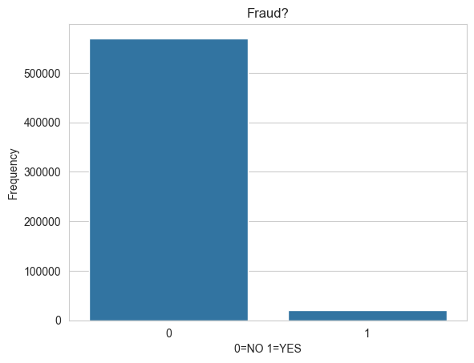

```python
plt.title('Fraud?')
sns.countplot(x=fraudmer2.isFraud)
plt.xlabel('0=NO 1=YES')
plt.ylabel('Frequency')
plt.show()
```

se puede notar que existe un gran desbalance de datos, donde en menos del 10% de datos se detecto que se cometio fraude, siendo indicado por 1

```python
fraudmer2.P_emaildomain.value_counts()
```

```
P_emaildomain
gmail.com           228355
yahoo.com           100934
hotmail.com          45250
anonymous.com        36998
aol.com              28289
comcast.net           7888
icloud.com            6267
outlook.com           5096
msn.com               4092
att.net               4033
live.com              3041
sbcglobal.net         2970
verizon.net           2705
ymail.com             2396
bellsouth.net         1909
yahoo.com.mx          1543
me.com                1522
cox.net               1393
optonline.net         1011
charter.net            816
live.com.mx            749
rocketmail.com         664
mail.com               559
earthlink.net          514
gmail                  496
outlook.es             438
mac.com                436
juno.com               322
aim.com                315
hotmail.es             305
roadrunner.com         305
windstream.net         305
hotmail.fr             295
frontier.com           280
embarqmail.com         260
web.de                 240
netzero.com            230
twc.com                230
prodigy.net.mx         207
centurylink.net        205
netzero.net            196
frontiernet.net        195
q.com                  189
suddenlink.net         175
cfl.rr.com             172
sc.rr.com              164
cableone.net           159
gmx.de                 149
yahoo.fr               143
yahoo.es               134
hotmail.co.uk          112
protonmail.com          76
yahoo.de                74
ptd.net                 68
live.fr                 56
yahoo.co.uk             49
hotmail.de              43
servicios-ta.com        35
yahoo.co.jp             32
Name: count, dtype: int64
```

```python
fraudmer2.ProductCD.value_counts()
```

```
ProductCD
W    439670
C     68519
R     37699
H     33024
S     11628
Name: count, dtype: int64
```

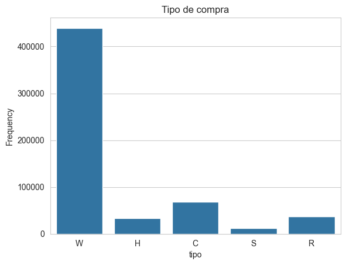

```python
plt.title('Tipo de compra')
sns.countplot(x=fraudmer2.ProductCD)
plt.xlabel('tipo')
plt.ylabel('Frequency')
plt.show()
```

```python
fraudmer2.ProductCD.describe()
```

```
count     590540
unique         5
top            W
freq      439670
Name: ProductCD, dtype: object
```

Revisando el tipo de producto o compra que se reviso, se puede notar que la mayoria de compras fueron de tipo W,

```python
fraudmer2.card4.value_counts()
```

```
card4
visa                384767
mastercard          189217
american express      8328
discover              6651
Name: count, dtype: int64
```

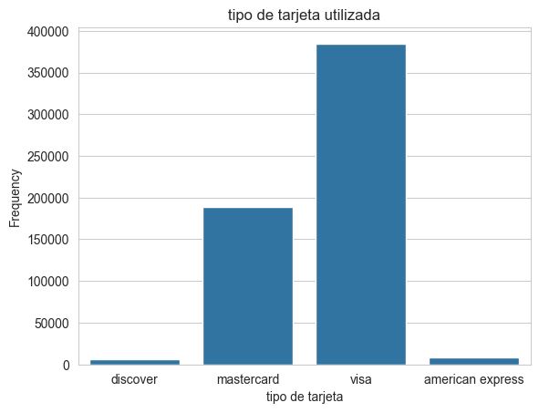

```python
plt.title('tipo de tarjeta utilizada')
sns.countplot(x=fraudmer2.card4)
plt.xlabel('tipo de tarjeta')
plt.ylabel('Frequency')
plt.show()
```

```python
fraudmer2.card4.describe()
```

```
count     588963
unique         4
top         visa
freq      384767
Name: card4, dtype: object
```

en este caso, revisando el tipo de tarjeta utilizada, el tipo mas usado fue de tipo VISA

# ahora seria realizar el analisis exploratoria del segundo dataset, el relacionado a windspeed

```python
wind= pd.read_csv('C:/Users/cacolpas/Desktop/parcial/wind speed/data_treino_dv_df_2000_2010.csv')
wind
```

|  | HORA (UTC) | VENTO, DIREï¿½ï¿½O HORARIA (gr) (ï¿½ (gr)) | VENTO, VELOCIDADE HORARIA (m/s) | UMIDADE REL. MAX. NA HORA ANT. (AUT) (%) | UMIDADE REL. MIN. NA HORA ANT. (AUT) (%) | TEMPERATURA Mï¿½XIMA NA HORA ANT. (AUT) (ï¿½C) | TEMPERATURA Mï¿½NIMA NA HORA ANT. (AUT) (ï¿½C) | UMIDADE RELATIVA DO AR, HORARIA (%) | PRESSAO ATMOSFERICA AO NIVEL DA ESTACAO, HORARIA (mB) | PRECIPITAï¿½ï¿½O TOTAL, HORï¿½RIO (mm) | VENTO, RAJADA MAXIMA (m/s) | PRESSï¿½O ATMOSFERICA MAX.NA HORA ANT. (AUT) (mB) | PRESSï¿½O ATMOSFERICA MIN. NA HORA ANT. (AUT) (mB) |
| --- | --- | --- | --- | --- | --- | --- | --- | --- | --- | --- | --- | --- | --- |
| 0 | 12:00 | 0.809017 | 1.8 | 69.0 | 60.0 | 22.6 | 20.7 | 61.0 | 888.2 | 0.0 | 3.8 | 888.2 | 887.7 |
| 1 | 13:00 | 0.965926 | 2.7 | 62.0 | 55.0 | 24.2 | 22.5 | 55.0 | 888.4 | 0.0 | 4.7 | 888.4 | 888.2 |
| 2 | 14:00 | 0.891007 | 2.0 | 56.0 | 50.0 | 25.5 | 24.3 | 51.0 | 888.1 | 0.0 | 4.9 | 888.4 | 888.1 |
| 3 | 15:00 | 0.848048 | 2.5 | 52.0 | 44.0 | 27.4 | 25.0 | 44.0 | 887.4 | 0.0 | 5.8 | 888.1 | 887.4 |
| 4 | 16:00 | 0.224951 | 2.4 | 50.0 | 43.0 | 27.1 | 25.5 | 46.0 | 886.5 | 0.0 | 5.8 | 887.4 | 886.5 |
| ... | ... | ... | ... | ... | ... | ... | ... | ... | ... | ... | ... | ... | ... |
| 87688 | 19:00 | -0.615661 | 5.6 | 83.0 | 78.0 | 21.8 | 21.1 | 80.0 | 879.1 | 0.0 | 12.3 | 879.8 | 879.1 |
| 87689 | 20:00 | -0.469472 | 4.9 | 84.0 | 79.0 | 21.7 | 21.0 | 84.0 | 879.2 | 0.0 | 9.9 | 879.2 | 878.9 |
| 87690 | 21:00 | -0.484810 | 4.5 | 86.0 | 82.0 | 21.2 | 20.6 | 86.0 | 879.7 | 0.0 | 8.9 | 879.8 | 879.2 |
| 87691 | 22:00 | -0.484810 | 3.2 | 88.0 | 85.0 | 20.6 | 20.2 | 88.0 | 880.5 | 0.0 | 8.0 | 880.5 | 879.6 |
| 87692 | 23:00 | -0.573576 | 2.3 | 95.0 | 88.0 | 20.2 | 19.3 | 95.0 | 881.1 | 0.6 | 7.5 | 881.1 | 880.5 |

87693 rows × 13 columns

```python
print(wind.columns.values)
```

```
['HORA (UTC)' 'VENTO, DIREï¿½ï¿½O HORARIA (gr) (ï¿½ (gr))'
 'VENTO, VELOCIDADE HORARIA (m/s)'
 'UMIDADE REL. MAX. NA HORA ANT. (AUT) (%)'
 'UMIDADE REL. MIN. NA HORA ANT. (AUT) (%)'
 'TEMPERATURA Mï¿½XIMA NA HORA ANT. (AUT) (ï¿½C)'
 'TEMPERATURA Mï¿½NIMA NA HORA ANT. (AUT) (ï¿½C)'
 'UMIDADE RELATIVA DO AR, HORARIA (%)'
 'PRESSAO ATMOSFERICA AO NIVEL DA ESTACAO, HORARIA (mB)'
 'PRECIPITAï¿½ï¿½O TOTAL, HORï¿½RIO (mm)' 'VENTO, RAJADA MAXIMA (m/s)'
 'PRESSï¿½O ATMOSFERICA MAX.NA HORA ANT. (AUT) (mB)'
 'PRESSï¿½O ATMOSFERICA MIN. NA HORA ANT. (AUT) (mB)']
```

```python
wind.shape
```

```
(87693, 13)
```

```python
wind.head()
```

|  | HORA (UTC) | VENTO, DIREï¿½ï¿½O HORARIA (gr) (ï¿½ (gr)) | VENTO, VELOCIDADE HORARIA (m/s) | UMIDADE REL. MAX. NA HORA ANT. (AUT) (%) | UMIDADE REL. MIN. NA HORA ANT. (AUT) (%) | TEMPERATURA Mï¿½XIMA NA HORA ANT. (AUT) (ï¿½C) | TEMPERATURA Mï¿½NIMA NA HORA ANT. (AUT) (ï¿½C) | UMIDADE RELATIVA DO AR, HORARIA (%) | PRESSAO ATMOSFERICA AO NIVEL DA ESTACAO, HORARIA (mB) | PRECIPITAï¿½ï¿½O TOTAL, HORï¿½RIO (mm) | VENTO, RAJADA MAXIMA (m/s) | PRESSï¿½O ATMOSFERICA MAX.NA HORA ANT. (AUT) (mB) | PRESSï¿½O ATMOSFERICA MIN. NA HORA ANT. (AUT) (mB) |
| --- | --- | --- | --- | --- | --- | --- | --- | --- | --- | --- | --- | --- | --- |
| 0 | 12:00 | 0.809017 | 1.8 | 69.0 | 60.0 | 22.6 | 20.7 | 61.0 | 888.2 | 0.0 | 3.8 | 888.2 | 887.7 |
| 1 | 13:00 | 0.965926 | 2.7 | 62.0 | 55.0 | 24.2 | 22.5 | 55.0 | 888.4 | 0.0 | 4.7 | 888.4 | 888.2 |
| 2 | 14:00 | 0.891007 | 2.0 | 56.0 | 50.0 | 25.5 | 24.3 | 51.0 | 888.1 | 0.0 | 4.9 | 888.4 | 888.1 |
| 3 | 15:00 | 0.848048 | 2.5 | 52.0 | 44.0 | 27.4 | 25.0 | 44.0 | 887.4 | 0.0 | 5.8 | 888.1 | 887.4 |
| 4 | 16:00 | 0.224951 | 2.4 | 50.0 | 43.0 | 27.1 | 25.5 | 46.0 | 886.5 | 0.0 | 5.8 | 887.4 | 886.5 |

se cambia el formato de hora para que sea mas sencillo manejar los datos

```python
wind['HORA (UTC)'] = wind['HORA (UTC)'].str.replace(r':\d+', '', regex=True)
```

```python
wind
```

|  | HORA (UTC) | VENTO, DIREï¿½ï¿½O HORARIA (gr) (ï¿½ (gr)) | VENTO, VELOCIDADE HORARIA (m/s) | UMIDADE REL. MAX. NA HORA ANT. (AUT) (%) | UMIDADE REL. MIN. NA HORA ANT. (AUT) (%) | TEMPERATURA Mï¿½XIMA NA HORA ANT. (AUT) (ï¿½C) | TEMPERATURA Mï¿½NIMA NA HORA ANT. (AUT) (ï¿½C) | UMIDADE RELATIVA DO AR, HORARIA (%) | PRESSAO ATMOSFERICA AO NIVEL DA ESTACAO, HORARIA (mB) | PRECIPITAï¿½ï¿½O TOTAL, HORï¿½RIO (mm) | VENTO, RAJADA MAXIMA (m/s) | PRESSï¿½O ATMOSFERICA MAX.NA HORA ANT. (AUT) (mB) | PRESSï¿½O ATMOSFERICA MIN. NA HORA ANT. (AUT) (mB) |
| --- | --- | --- | --- | --- | --- | --- | --- | --- | --- | --- | --- | --- | --- |
| 0 | 12 | 0.809017 | 1.8 | 69.0 | 60.0 | 22.6 | 20.7 | 61.0 | 888.2 | 0.0 | 3.8 | 888.2 | 887.7 |
| 1 | 13 | 0.965926 | 2.7 | 62.0 | 55.0 | 24.2 | 22.5 | 55.0 | 888.4 | 0.0 | 4.7 | 888.4 | 888.2 |
| 2 | 14 | 0.891007 | 2.0 | 56.0 | 50.0 | 25.5 | 24.3 | 51.0 | 888.1 | 0.0 | 4.9 | 888.4 | 888.1 |
| 3 | 15 | 0.848048 | 2.5 | 52.0 | 44.0 | 27.4 | 25.0 | 44.0 | 887.4 | 0.0 | 5.8 | 888.1 | 887.4 |
| 4 | 16 | 0.224951 | 2.4 | 50.0 | 43.0 | 27.1 | 25.5 | 46.0 | 886.5 | 0.0 | 5.8 | 887.4 | 886.5 |
| ... | ... | ... | ... | ... | ... | ... | ... | ... | ... | ... | ... | ... | ... |
| 87688 | 19 | -0.615661 | 5.6 | 83.0 | 78.0 | 21.8 | 21.1 | 80.0 | 879.1 | 0.0 | 12.3 | 879.8 | 879.1 |
| 87689 | 20 | -0.469472 | 4.9 | 84.0 | 79.0 | 21.7 | 21.0 | 84.0 | 879.2 | 0.0 | 9.9 | 879.2 | 878.9 |
| 87690 | 21 | -0.484810 | 4.5 | 86.0 | 82.0 | 21.2 | 20.6 | 86.0 | 879.7 | 0.0 | 8.9 | 879.8 | 879.2 |
| 87691 | 22 | -0.484810 | 3.2 | 88.0 | 85.0 | 20.6 | 20.2 | 88.0 | 880.5 | 0.0 | 8.0 | 880.5 | 879.6 |
| 87692 | 23 | -0.573576 | 2.3 | 95.0 | 88.0 | 20.2 | 19.3 | 95.0 | 881.1 | 0.6 | 7.5 | 881.1 | 880.5 |

87693 rows × 13 columns

```python
wind.isnull().sum()
```

```
HORA (UTC)                                               0
VENTO, DIREï¿½ï¿½O HORARIA (gr) (ï¿½ (gr))               0
VENTO, VELOCIDADE HORARIA (m/s)                          0
UMIDADE REL. MAX. NA HORA ANT. (AUT) (%)                 0
UMIDADE REL. MIN. NA HORA ANT. (AUT) (%)                 0
TEMPERATURA Mï¿½XIMA NA HORA ANT. (AUT) (ï¿½C)           0
TEMPERATURA Mï¿½NIMA NA HORA ANT. (AUT) (ï¿½C)           0
UMIDADE RELATIVA DO AR, HORARIA (%)                      0
PRESSAO ATMOSFERICA AO NIVEL DA ESTACAO, HORARIA (mB)    0
PRECIPITAï¿½ï¿½O TOTAL, HORï¿½RIO (mm)                   0
VENTO, RAJADA MAXIMA (m/s)                               0
PRESSï¿½O ATMOSFERICA MAX.NA HORA ANT. (AUT) (mB)        0
PRESSï¿½O ATMOSFERICA MIN. NA HORA ANT. (AUT) (mB)       0
dtype: int64
```

```python
# Eliminar filas vacías (aquellas que contienen al menos un valor NaN)
df_clean2 = wind.dropna()

# Mostrar el DataFrame resultante sin filas vacías
print(df_clean2)
```

```
      HORA (UTC)  VENTO, DIREï¿½ï¿½O HORARIA (gr) (ï¿½ (gr))  \
0             12                                    0.809017
1             13                                    0.965926
2             14                                    0.891007
3             15                                    0.848048
4             16                                    0.224951
...          ...                                         ...
87688         19                                   -0.615661
87689         20                                   -0.469472
87690         21                                   -0.484810
87691         22                                   -0.484810
87692         23                                   -0.573576

       VENTO, VELOCIDADE HORARIA (m/s)  \
0                                  1.8
```

[output cut: 129 more lines]

en este caso, a diferencia del dataset anterior, no existen datos vacios, pero debido a la forma que se llaman las columnas, seria mejor renombrarlas para un mejor manejo, como tambien una mejor graficacion

```python
nombres_nuevos = {'HORA (UTC)': 'HORA','VENTO, DIREï¿½ï¿½O HORARIA (gr) (ï¿½ (gr))': 'gr',
                  'VENTO, VELOCIDADE HORARIA (m/s)': 'm/s', 'UMIDADE REL. MAX. NA HORA ANT. (AUT) (%)': 'MAX AUT%','UMIDADE REL. MIN. NA HORA ANT. (AUT) (%)':'MIN AUT%',
                  'TEMPERATURA Mï¿½XIMA NA HORA ANT. (AUT) (ï¿½C)': 'TEMP MAX AUT','TEMPERATURA Mï¿½NIMA NA HORA ANT. (AUT) (ï¿½C)': 'TEMP MIN AUT',
                  'UMIDADE RELATIVA DO AR, HORARIA (%)':'HUMEDADRELA','PRESSAO ATMOSFERICA AO NIVEL DA ESTACAO, HORARIA (mB)':'PRECION MB',
                  'PRECIPITAï¿½ï¿½O TOTAL, HORï¿½RIO (mm)': 'PRECI MM','VENTO, RAJADA MAXIMA (m/s)': 'VIENTO MAX','PRESSï¿½O ATMOSFERICA MAX.NA HORA ANT. (AUT) (mB)': 'PRESION MAX',
                  'PRESSï¿½O ATMOSFERICA MIN. NA HORA ANT. (AUT) (mB)': 'PRESION MIN'}
```

```python
wind.rename(columns=nombres_nuevos, inplace=True)
wind
```

|  | HORA | gr | m/s | MAX AUT% | MIN AUT% | TEMP MAX AUT | TEMP MIN AUT | HUMEDADRELA | PRECION MB | PRECI MM | VIENTO MAX | PRESION MAX | PRESION MIN |
| --- | --- | --- | --- | --- | --- | --- | --- | --- | --- | --- | --- | --- | --- |
| 0 | 12 | 0.809017 | 1.8 | 69.0 | 60.0 | 22.6 | 20.7 | 61.0 | 888.2 | 0.0 | 3.8 | 888.2 | 887.7 |
| 1 | 13 | 0.965926 | 2.7 | 62.0 | 55.0 | 24.2 | 22.5 | 55.0 | 888.4 | 0.0 | 4.7 | 888.4 | 888.2 |
| 2 | 14 | 0.891007 | 2.0 | 56.0 | 50.0 | 25.5 | 24.3 | 51.0 | 888.1 | 0.0 | 4.9 | 888.4 | 888.1 |
| 3 | 15 | 0.848048 | 2.5 | 52.0 | 44.0 | 27.4 | 25.0 | 44.0 | 887.4 | 0.0 | 5.8 | 888.1 | 887.4 |
| 4 | 16 | 0.224951 | 2.4 | 50.0 | 43.0 | 27.1 | 25.5 | 46.0 | 886.5 | 0.0 | 5.8 | 887.4 | 886.5 |
| ... | ... | ... | ... | ... | ... | ... | ... | ... | ... | ... | ... | ... | ... |
| 87688 | 19 | -0.615661 | 5.6 | 83.0 | 78.0 | 21.8 | 21.1 | 80.0 | 879.1 | 0.0 | 12.3 | 879.8 | 879.1 |
| 87689 | 20 | -0.469472 | 4.9 | 84.0 | 79.0 | 21.7 | 21.0 | 84.0 | 879.2 | 0.0 | 9.9 | 879.2 | 878.9 |
| 87690 | 21 | -0.484810 | 4.5 | 86.0 | 82.0 | 21.2 | 20.6 | 86.0 | 879.7 | 0.0 | 8.9 | 879.8 | 879.2 |
| 87691 | 22 | -0.484810 | 3.2 | 88.0 | 85.0 | 20.6 | 20.2 | 88.0 | 880.5 | 0.0 | 8.0 | 880.5 | 879.6 |
| 87692 | 23 | -0.573576 | 2.3 | 95.0 | 88.0 | 20.2 | 19.3 | 95.0 | 881.1 | 0.6 | 7.5 | 881.1 | 880.5 |

87693 rows × 13 columns

ahora que esta organizado y se redujeron los nombres, se ve mas ordenado el dataset

```python
wind.head()
```

|  | HORA | gr | m/s | MAX AUT% | MIN AUT% | TEMP MAX AUT | TEMP MIN AUT | HUMEDADRELA | PRECION MB | PRECI MM | VIENTO MAX | PRESION MAX | PRESION MIN |
| --- | --- | --- | --- | --- | --- | --- | --- | --- | --- | --- | --- | --- | --- |
| 0 | 12 | 0.809017 | 1.8 | 69.0 | 60.0 | 22.6 | 20.7 | 61.0 | 888.2 | 0.0 | 3.8 | 888.2 | 887.7 |
| 1 | 13 | 0.965926 | 2.7 | 62.0 | 55.0 | 24.2 | 22.5 | 55.0 | 888.4 | 0.0 | 4.7 | 888.4 | 888.2 |
| 2 | 14 | 0.891007 | 2.0 | 56.0 | 50.0 | 25.5 | 24.3 | 51.0 | 888.1 | 0.0 | 4.9 | 888.4 | 888.1 |
| 3 | 15 | 0.848048 | 2.5 | 52.0 | 44.0 | 27.4 | 25.0 | 44.0 | 887.4 | 0.0 | 5.8 | 888.1 | 887.4 |
| 4 | 16 | 0.224951 | 2.4 | 50.0 | 43.0 | 27.1 | 25.5 | 46.0 | 886.5 | 0.0 | 5.8 | 887.4 | 886.5 |

```python
wind.HORA.value_counts()
```

```
HORA
01    3683
20    3683
02    3683
18    3672
03    3671
16    3668
17    3667
22    3667
19    3666
23    3665
15    3662
04    3659
21    3654
05    3654
06    3649
14    3648
00    3645
13    3644
12    3642
07    3638
08    3631
11    3625
10    3612
09    3605
Name: count, dtype: int64
```

```python
wind.nunique()
```

```
HORA             24
gr              290
m/s              89
MAX AUT%         89
MIN AUT%         89
TEMP MAX AUT    251
TEMP MIN AUT    247
HUMEDADRELA      90
PRECION MB      446
PRECI MM        154
VIENTO MAX      176
PRESION MAX     415
PRESION MIN     425
dtype: int64
```

```python
wind.HORA.describe()
```

```
count     87693
unique       24
top          01
freq       3683
Name: HORA, dtype: object
```

en el caso de contar las horas, este dataset se encuentra balanceado

```python
wind.gr.value_counts()
```

```
gr
 0.999391    1698
 0.997564    1671
 0.996195    1668
 0.998630    1655
 0.999848    1631
             ...
-0.788011      56
-0.857167      54
-0.743145      53
-0.798636      53
-0.656059      51
Name: count, Length: 290, dtype: int64
```

```python
from scipy.stats import kurtosis
```

```
Column:  HORA
Skew: -0.0
Kurtosis:  -1.21
```

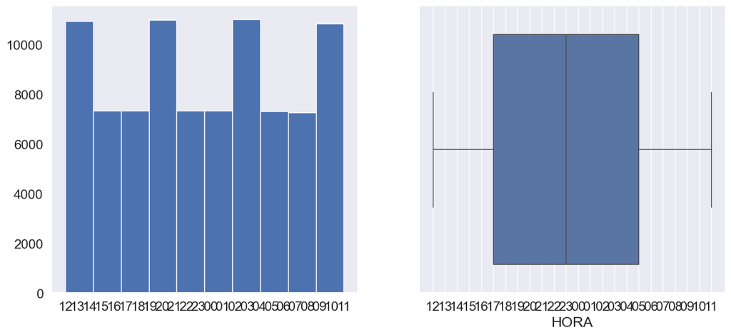

```
Column:  gr
Skew: -0.86
Kurtosis:  -0.82
```

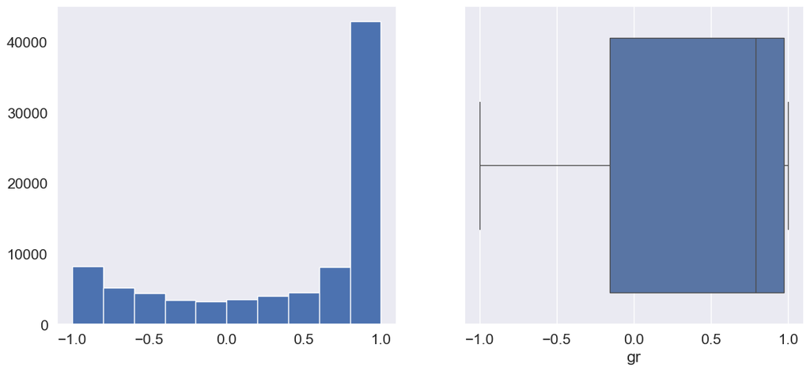

```
Column:  m/s
Skew: 0.37
Kurtosis:  -0.11
```

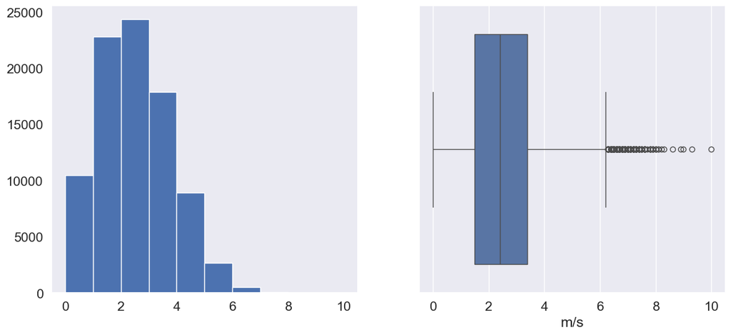

```
Column:  MAX AUT%
Skew: -0.48
Kurtosis:  -0.78
```

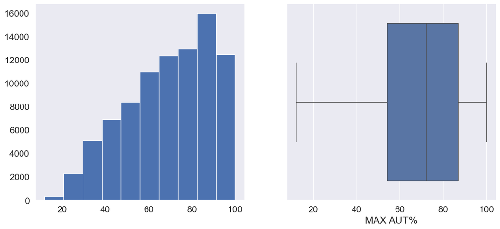

```
Column:  MIN AUT%
Skew: -0.23
Kurtosis:  -0.96
```

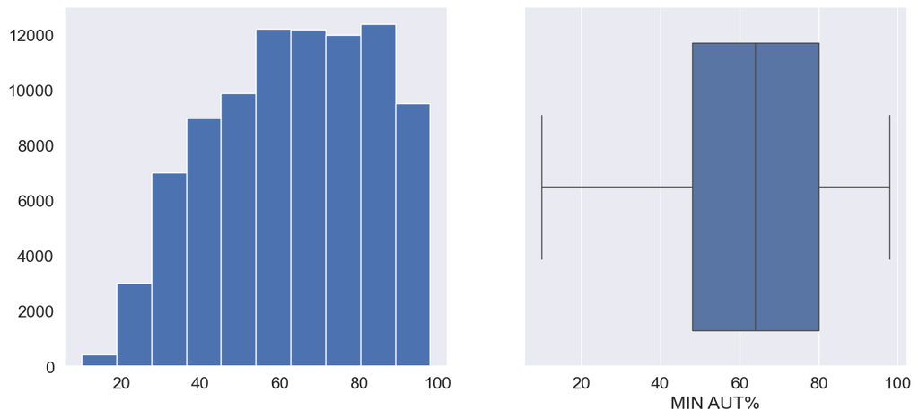

```
Column:  TEMP MAX AUT
Skew: 0.26
Kurtosis:  -0.42
```

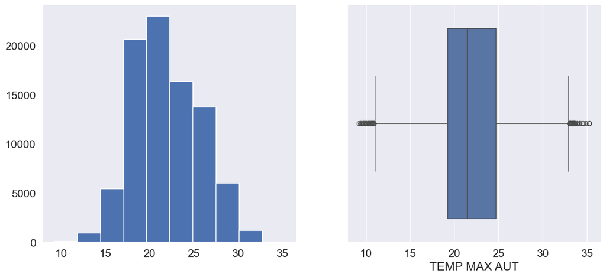

```
Column:  TEMP MIN AUT
Skew: 0.24
Kurtosis:  -0.12
```

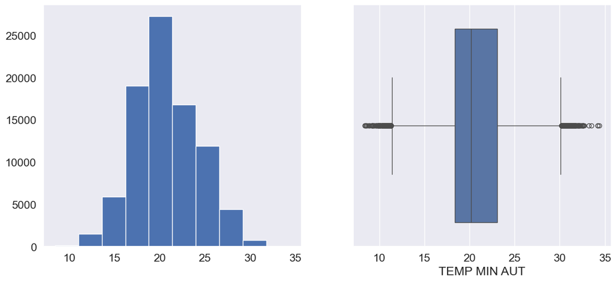

```
Column:  HUMEDADRELA
Skew: -0.35
Kurtosis:  -0.89
```

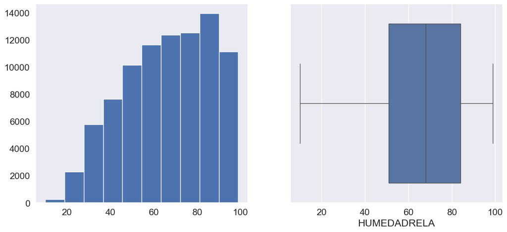

```
Column:  PRECION MB
Skew: 6.18
Kurtosis:  179.64
```

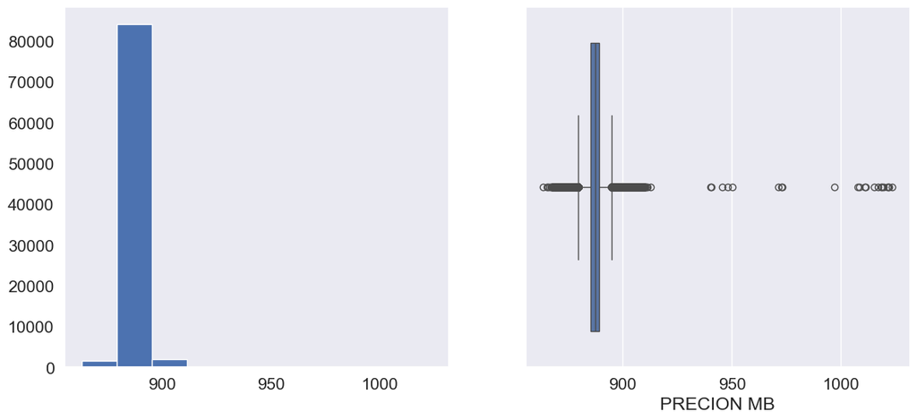

```
Column:  PRECI MM
Skew: 17.65
Kurtosis:  476.4
```

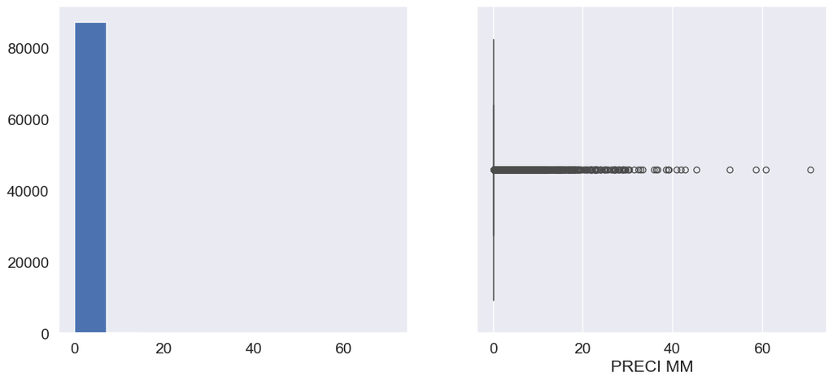

```
Column:  VIENTO MAX
Skew: 0.41
Kurtosis:  0.11
```

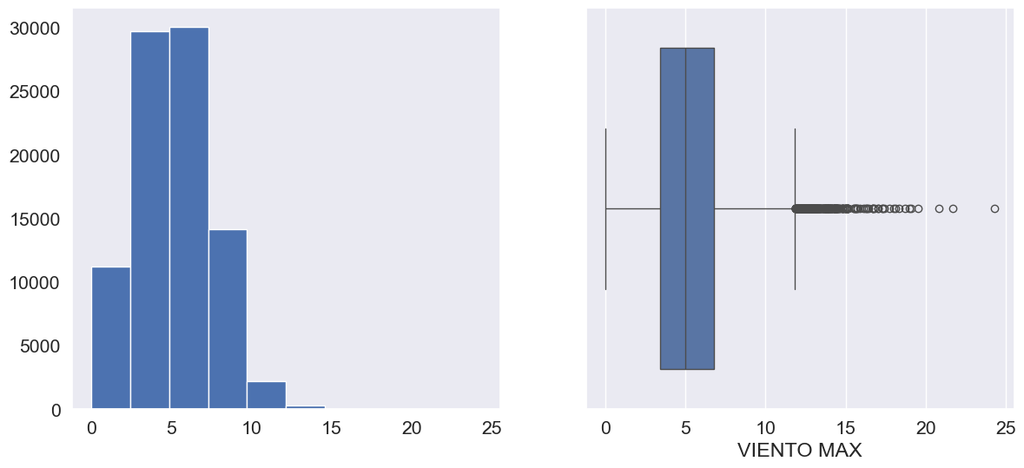

```
Column:  PRESION MAX
Skew: 1.02
Kurtosis:  5.82
```

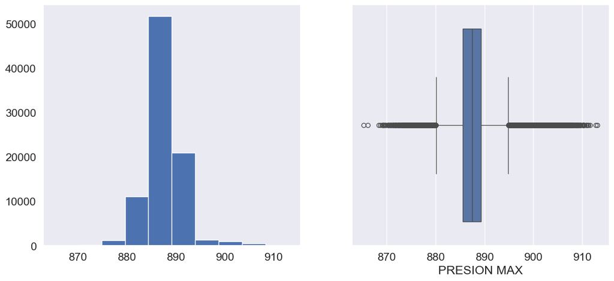

```
Column:  PRESION MIN
Skew: 0.33
Kurtosis:  4.91
```

[1 more figures not shown]

```python
sns.set(font_scale=1.4)
for col in wind:
    print('Column: ', col)
    print('Skew:', round(wind[col].skew(), 2))
    print('Kurtosis: ', round(wind[col].kurtosis(), 2))
    plt.figure(figsize = (14, 6))
    plt.subplot(1, 2, 1)
    wind[col].hist(grid=False)
    plt.subplot(1, 2, 2)
    sns.boxplot(x=wind[col])
    plt.show()
```

En primer medida, viendo las graficas, estas parecen desbalanceadas, pero debido a la distribucion de los datos en los cuales algunos tienen registrados el min y el max de una variable, es entendible la tendencia de los datos

```python
import statsmodels.api as sm
from statsmodels.stats.outliers_influence import variance_inflation_factor


wind2 = wind[['MAX AUT%', 'MIN AUT%']]

wind2 = sm.add_constant(wind2)

vif = pd.DataFrame()
vif["Features"] = wind2.columns
vif["VIF"] = [variance_inflation_factor(wind2.values, i) for i in range(wind2.shape[1])]

print(vif)
```

```
   Features        VIF
0     const  15.356505
1  MAX AUT%  21.848798
2  MIN AUT%  21.848798
```

```python
wind2 = wind[['gr','MAX AUT%', 'MIN AUT%','TEMP MAX AUT','TEMP MIN AUT','HUMEDADRELA','PRECION MB','PRECI MM','VIENTO MAX','PRESION MAX','PRESION MIN']]

wind2 = sm.add_constant(wind2)

vif = pd.DataFrame()
vif["Features"] = wind2.columns
vif["VIF"] = [variance_inflation_factor(wind2.values, i) for i in range(wind2.shape[1])]

print(vif)
```

```
        Features           VIF
0          const  83694.578065
1             gr      1.311831
2       MAX AUT%     77.771236
3       MIN AUT%     80.560353
4   TEMP MAX AUT     68.101834
5   TEMP MIN AUT     57.271259
6    HUMEDADRELA     51.849641
7     PRECION MB      4.900592
8       PRECI MM      1.122099
9     VIENTO MAX      1.275703
10   PRESION MAX     16.001623
11   PRESION MIN     16.410043
```

```python
wind2 = wind[['PRESION MAX', 'PRESION MIN']]

wind2 = sm.add_constant(wind2)

vif = pd.DataFrame()
vif["Features"] = wind2.columns
vif["VIF"] = [variance_inflation_factor(wind2.values, i) for i in range(wind2.shape[1])]

print(vif)
```

```
      Features           VIF
0        const  62068.605769
1  PRESION MAX     14.466669
2  PRESION MIN     14.466669
```

```python
from sklearn.neighbors import KNeighborsRegressor
```

```python
X=wind.data
y=wind.target
X_train, X_test, y_train, y_test = train_test_split(X, y, random_state=0)
reg = KNeighborsRegressor(n_neighbors=3)
reg.fit(X_train, y_train)
```

[output not shown]